# Lab 2 - Multiple Regression

1/21/2019

Linear regression is one of the most commonly used predictive modelling techniques. The aim of linear regression is to find a mathematical equation for a continuous response variable Y (can be dichotomous) as a function of one or more explanatory X variable(s).

This mathematical equation can be generalised as follows:

$$Y = \beta_{0} + \beta_{1} X_{1} + \beta_{2} X_{2} + \epsilon$$
where, $\beta_{0}$ is the intercept and the $\beta_{i}$’s are slope coefficients.

Collectively, they are called regression coefficients and ϵ is the error term, the part of Y the regression model is unable to explain.

For this analysis, we will use the `mtcars` dataset that comes with R by default.

You can access this dataset by typing in `mtcars` in your R console. For this exerciese we will want to load it into our environment and save it as a discrete object. We can get a glimpse of the data before loading it in.

```r
head(mtcars)  # display the first 6 observations
```

```
##                    mpg cyl disp  hp drat    wt  qsec vs am gear carb
## Mazda RX4         21.0   6  160 110 3.90 2.620 16.46  0  1    4    4
## Mazda RX4 Wag     21.0   6  160 110 3.90 2.875 17.02  0  1    4    4
## Datsun 710        22.8   4  108  93 3.85 2.320 18.61  1  1    4    1
## Hornet 4 Drive    21.4   6  258 110 3.08 3.215 19.44  1  0    3    1
## Hornet Sportabout 18.7   8  360 175 3.15 3.440 17.02  0  0    3    2
## Valiant           18.1   6  225 105 2.76 3.460 20.22  1  0    3    1
```

We can now proceed to load it in:

```r
raw_df <- data.frame(mtcars)
```

The goal here is to establish a mathematical equation for fuel economy as a function of a car’s curb weight and its horsepower rating. Deciding what variables are in our equations should be informed by theory. For this example, we want to estimate `mpg` as a function of `wt` and `hp`. Why? Well we expect that a car’s curb weight and its horsepower rating (how much power an engine has) impact its fuel economy.

But before we begin building the regression model, it is a good practice to analyse and understand the variables. The graphical analysis and correlation study below will help with this.

Typically, for each of the predictors, the following plots help visualise the patterns:

- Scatter plot: Visualise the linear relationship (if any) between the predictor and response variable.
- Box plot: To spot any outlier observations in the variable. Having outliers in your predictor can drastically affect the predictions as they can affect the direction/slope of the line of best fit.
- Density plot: To see the distribution of the predictor variable.

### Scatter Plots

Scatter plots can help visualise linear relationships between the response and predictor variables. Ideally, if you have many predictor variables, a scatter plot is drawn for each one of them against the response, along with the line of best fit as seen below.

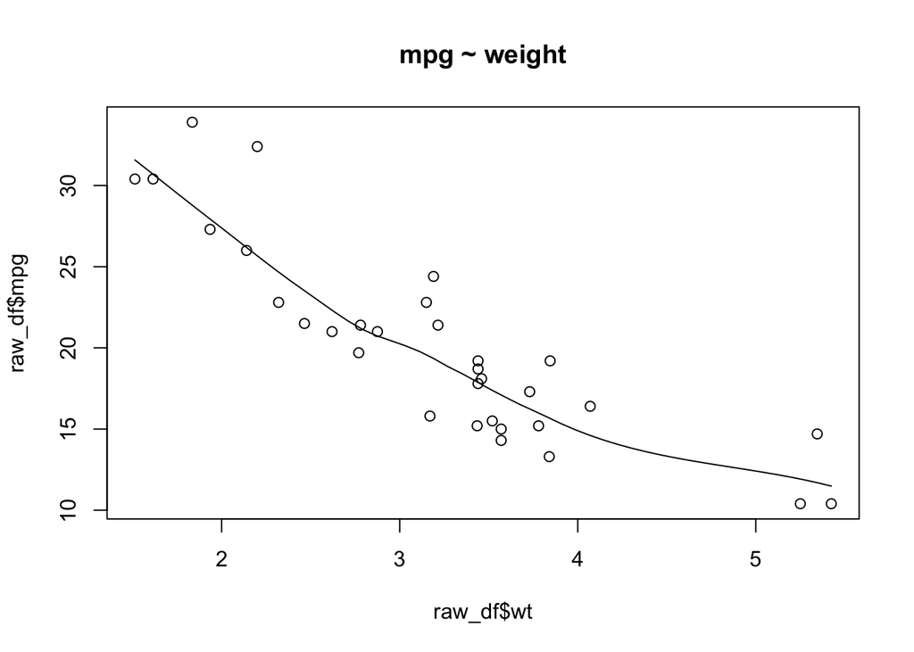

```r
scatter.smooth(x=raw_df$wt, y=raw_df$mpg, main="mpg ~ weight")  # scatterplot
```

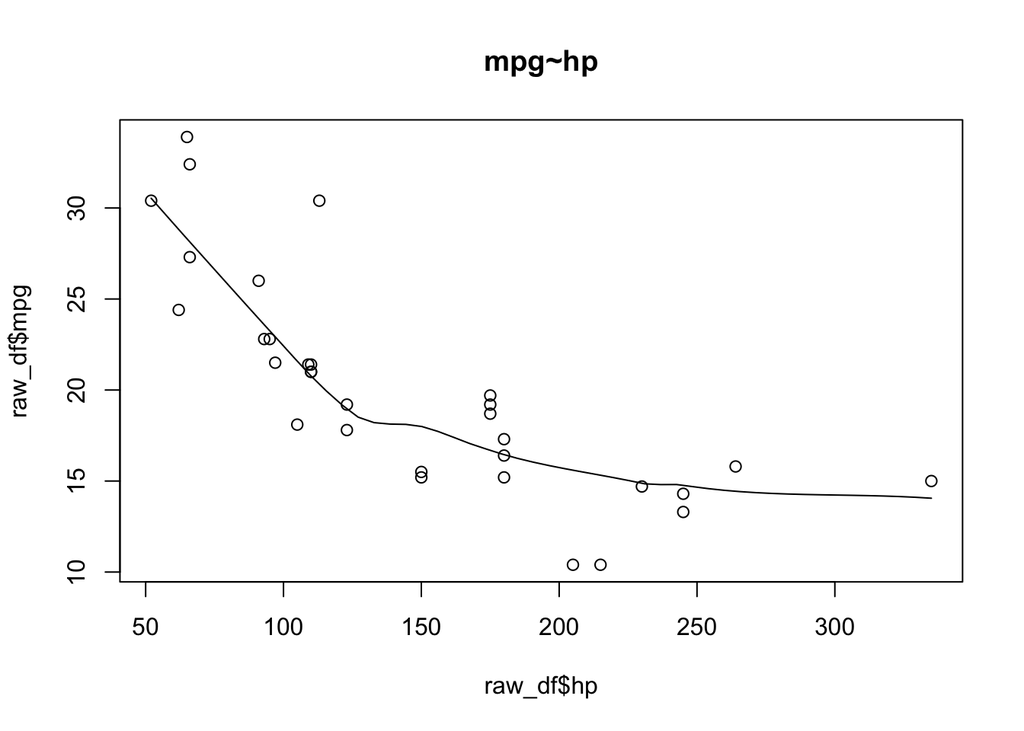

```r
scatter.smooth(x=raw_df$hp, y=raw_df$mpg, main="mpg~hp")
```

The scatter plot along with the smoothing line above suggests a (mostly) linear and negative relationship between fuel economy and a car’s weight, on the one hand, and fuel economy and horsepower, on the other. This is a good thing because one of the underlying assumptions of linear regression is that the relationship between the response and predictor variables is linear and additive.

### Box Plot

Generally, an outlier is any datapoint that lies outside the 1.5 * inter quartile range (IQR). The IQR is calculated as the distance between the 25th percentile and 75th percentile values for that variable.

[figure not shown]

```r
par(mfrow = c(1, 3))

boxplot(raw_df$wt, main="Weight", sub=paste("Outlier rows: ", boxplot.stats(cars$speed)$out))  # box plot for 'weight'

boxplot(raw_df$hp, main="Horsepower", sub=paste("Outlier rows: ", boxplot.stats(cars$dist)$out))  # box plot for 'hp'

boxplot(raw_df$mpg, main="Fuel Economy", sub=paste("Outlier rows: ", boxplot.stats(cars$dist)$out))  # box plot for 'mpg'
```

### Density Plot

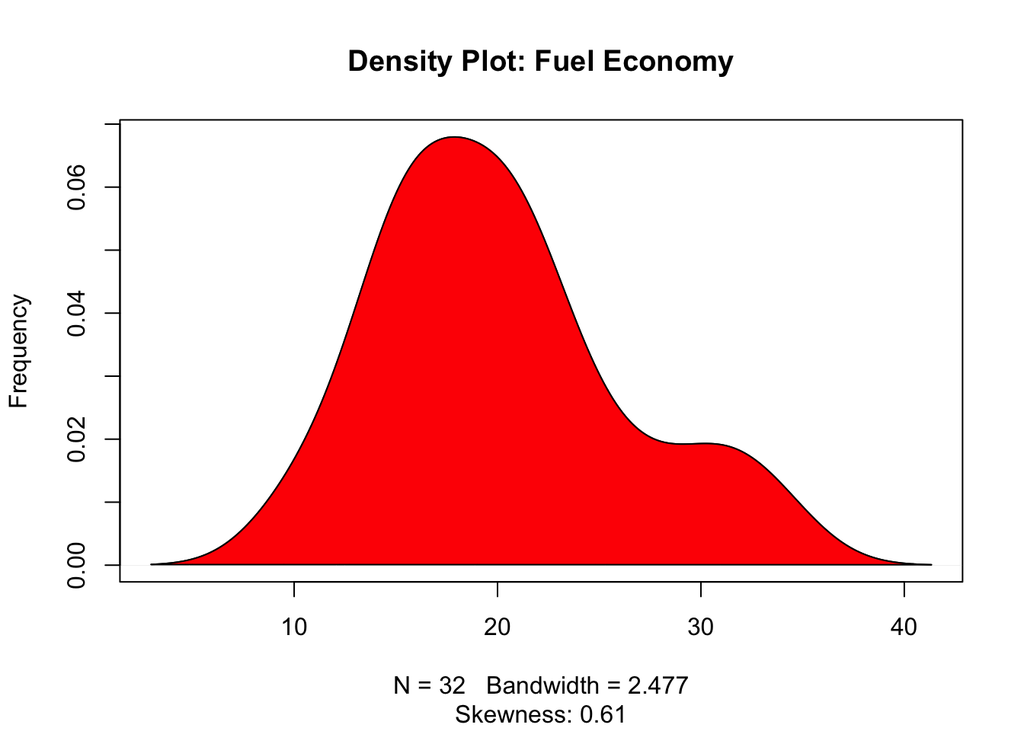

```r
library(e1071)  # for skewness function

plot(density(raw_df$mpg), main="Density Plot: Fuel Economy", ylab="Frequency", sub=paste("Skewness:", round(e1071::skewness(raw_df$mpg), 2)))  # density plot for 'mpg'
polygon(density(raw_df$mpg), col="red")
```

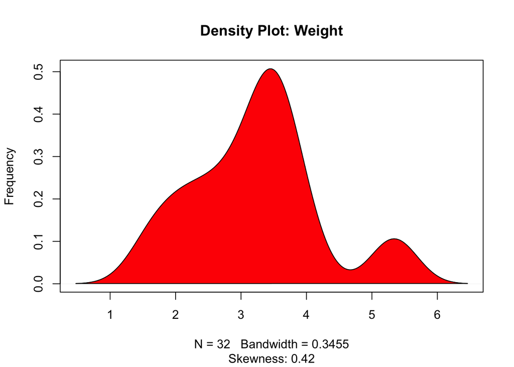

```r
plot(density(raw_df$wt), main="Density Plot: Weight", ylab="Frequency", sub=paste("Skewness:", round(e1071::skewness(raw_df$wt), 2)))  # density plot for 'wt'
polygon(density(raw_df$wt), col="red")
```

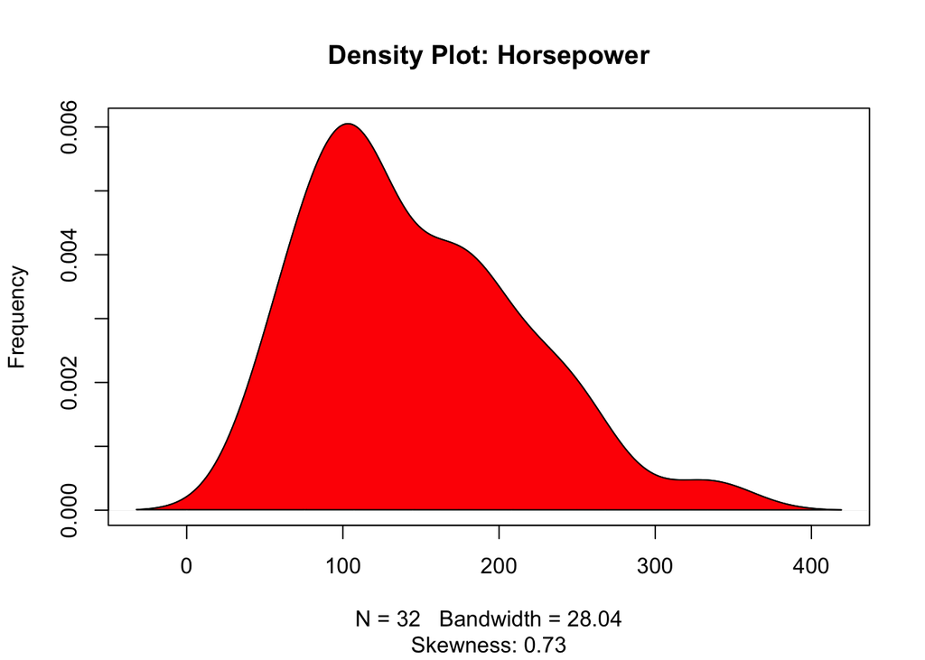

```r
plot(density(raw_df$hp), main="Density Plot: Horsepower", ylab="Frequency", sub=paste("Skewness:", round(e1071::skewness(raw_df$hp), 2)))  # density plot for 'hp'
polygon(density(raw_df$hp), col="red")
```